# Binomial Distributions in R

## 0.1 Libraries

```r
library(ggplot2)
```

# 1 Introduction

Binomial distributions have several qualities

- There is a fixed number of trials
- Each trial can have one of two possible outcomes
- The outcomes of each trial are independent of each other
- The probability of success is the same for each trial

A good example of this would be the number of heads after flipping a coin 20 times.

# 2 The Formula

In a binomial experiment the probability of exactly *X* successes in *n* trials is:

$$P(X) = \frac{n!}{(n-X)!X!}\cdot p^{X} \cdot q^{n-X}$$

Where:

- P(X) is the probability of the number of successes in *n* trials
- n is the number of trials
- X is the number of successes in *n* trials
- q is the probability of failure
- p is the probability of success

Note that this formula is fairly similar to the formula for combinations without replacement.

## 2.1 Example

So if we wanted the probability of 5 heads in 20 flips of a fair coin we’d do this:

$$P(\text{5 heads in 20 flips}) = \frac{20!}{(20-5)!5!} \cdot .5^{5} \cdot .5^{20-5} = 0.0147857666$$

This means that there is a 1.48% chance of getting 5 heads in 20 flips of a fair coin.

in R we would just enter: `dbinom(5,20,.5)`

See more below

# 3 Binomial functions in R

There are four binomial functions in R.

- dbinom(x, size, prob, log = FALSE)
- pbinom(q, size, prob, lower.tail = TRUE, log.p = FALSE)
- qbinom(p, size, prob, lower.tail = TRUE, log.p = FALSE)
- rbinom(n, size, prob)

**dbinom** will give the probability of a number of positive trials(x), from a number of total trials (size), based on the probability of the positive result (prob). For example we could find the probability of 5 heads (x=5), from a total of 20 total flips (size = 20), given that the coin is fair and the probability of heads is 0.5 (prob=0.5). dbinom(5, 20, 0.5)

**pbinom** will give the probability of less than or equal to OR greater than or equal to positive trials(q), from a number of total trials(size), and a probability of a positive outcome (prob). Note the lower.tail variable in the command. For example if we can find the probability that 5 or fewer heads (q = 5) will be flipped from a total of 20 flips (size = 20), and the coin is fair (prob = 0.5). In this case it’s 5 or fewer so lower.tail=TRUE. pbinom(5, 20, 0.5, lower.tail=TRUE)

**qbinom** is the opposite of pbinom. qbinom will give the number of positive trials less than or equal to a probability (p) of a positive outcomes, the size of the total number of trials (size), and the probability of a positive trial (prob). Note the lower.tail variable so we can have greater than or equal to a number of positive trials. So if we want to know the number of heads that we would get less than or equal to 10% of the time (p = .1), from a total number of 20 trials (size = 20), with a fair coin (prob = 0.5). qbinom(.1, 20, .5). If we wanted to get the deciles of 20 fair coin flips we would enter: qbinom(seq(0,1,.1), 20, .5)

**rbinom** will create a binomial distribution with a certain size (n), that has a trial size (size), and a probability of a positive outcome for each trial. For example we can create a vector of 1000 coin flips of a fair coin with this: rbinom(1000,1,.5). Or 1000 trials of a drug that has a 75% rate of success, and 20 patients per trial with this: rbinom(1000,20,.75)

## 3.1 Example dbinom

- dbinom(x, size, prob, log = FALSE)

In our hypothetical scenario there are 20 people randomly selected and nationally 5% of the population is afraid of being home alone at night. Now we want to know what the probability is that exactly 5 of these 20 are afraid of being home alone at night.

We use the dbinom function which works like this: dbinom(number of successes, size of sample, probability of success)

```r
dbinom(5, 20, 0.05)
```

```
## [1] 0.002244646
```

So this means that there is a .22% chance that 5 people will be afraid of being home alone at night from a sample of 20 people with a probability of 5%.  
We can also find the probability that someone will be afraid in each possible outcome, from 0 through 20.

```r
dbinom(0:20, 20, 0.05)
```

```
##  [1] 3.584859e-01 3.773536e-01 1.886768e-01 5.958215e-02 1.332759e-02
##  [6] 2.244646e-03 2.953482e-04 3.108928e-05 2.658952e-06 1.865931e-07
## [11] 1.080276e-08 5.168784e-10 2.040309e-11 6.608289e-13 1.739024e-14
## [16] 3.661102e-16 6.021550e-18 7.457027e-20 6.541252e-22 3.623962e-24
## [21] 9.536743e-27
```

This last one we can plot and we can see that the most likely outcomes in this scenario are that 1, 0, and the 2 people will be afraid from a sample of 20 people.

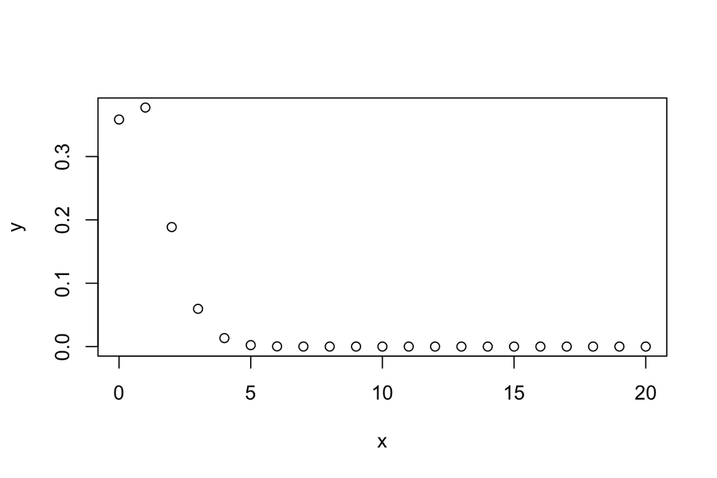

```r
y<-dbinom(0:20, 20, 0.05)
x<-(0:20)
plot(x,y)
```

And we can also plot this using ggplot2

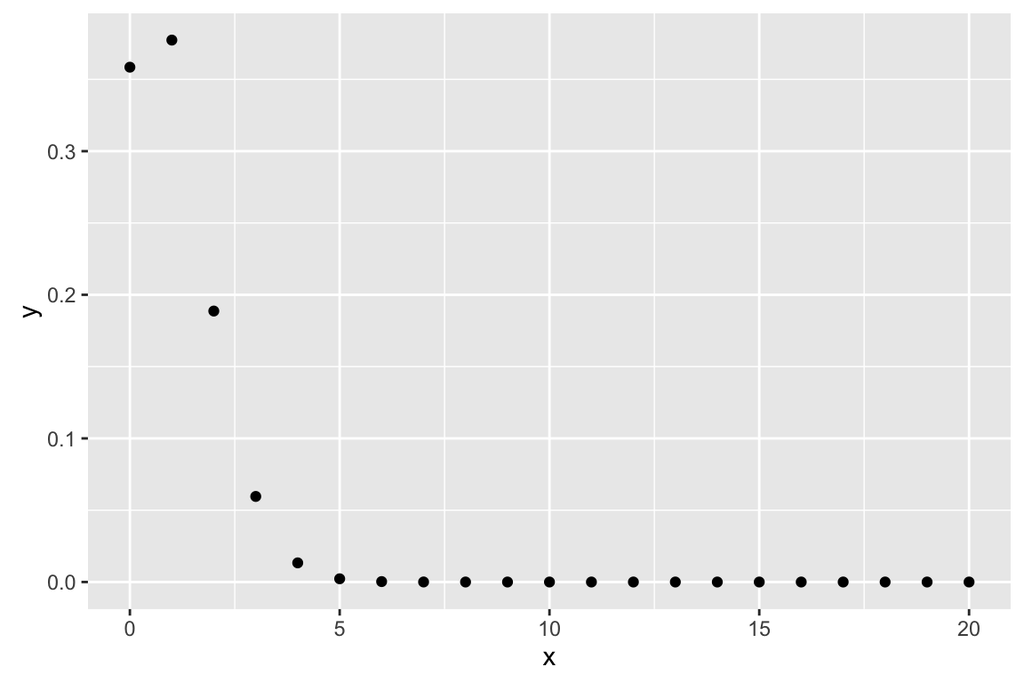

```r
library(ggplot2)
y<-dbinom(0:20, 20, 0.05)
x<-(0:20)
qplot(x,y)
```

Now we can make a plot which would show the probability of 0 through 100 people having a condition from a group of 100 randomly selected individuals where the probability of that condition is 35%.

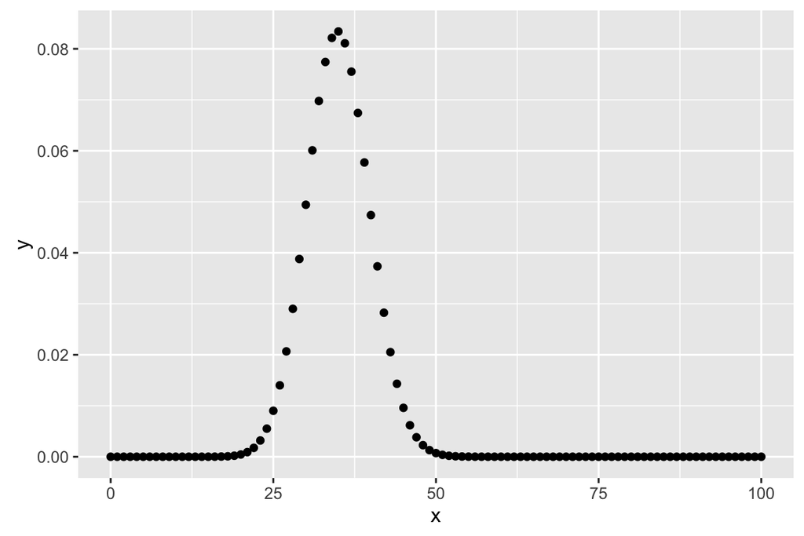

```r
y<-dbinom(0:100,100,.35)
x <-0:100
qplot(x,y)
```

## 3.2 Example pbinom

- pbinom(q, size, prob, lower.tail = TRUE, log.p = FALSE)

So in this example, we have a drug that has a success rate of 75%, we have a group of 20 people, and we want to know the probability that between 0 and 12 people in the group of 20 will respond positively to the drug.

```r
pbinom(12, 20, .75)
```

```
## [1] 0.1018119
```

And now we can find the probability of between 0 and x people will respond positively to this drug from a group of 20.

```r
pbinom(1:20, 20, .75)
##  [1] 5.547918e-11 1.610715e-09 2.960496e-08 3.865316e-07 3.813027e-06
##  [6] 2.951175e-05 1.837041e-04 9.353916e-04 3.942142e-03 1.386442e-02
## [11] 4.092517e-02 1.018119e-01 2.142181e-01 3.828273e-01 5.851585e-01
## [16] 7.748440e-01 9.087396e-01 9.756874e-01 9.968288e-01 1.000000e+00
```

And we can plot these probabilities

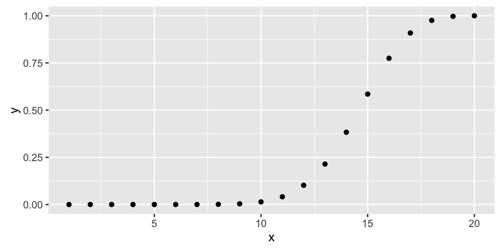

```r
y <- pbinom(1:20, 20, .75)
x <- 1:20
qplot(x,y)
```

## 3.3 Example qbinom

- qbinom(p, size, prob, lower.tail = TRUE, log.p = FALSE)

This will give us a quantile. This will give us the bottom quantile, or the bottom 10% percent of outcomes with a drug trial that has a 75% success rate and each trial has 20 patients. To put it another way 10% of trials will have between 0 and 12 patients respond positively to this treatment.

```r
qbinom(.1, 20, .75)
```

```
## [1] 12
```

If we wanted the number of patients with a positive response in the bottom 20% of trials we would enter this below. Or to put it another way, in 20% of the trials, between 0 and 13 people will respond positively to this drug treatment.

```r
qbinom(.2, 20,.75)
```

```
## [1] 13
```

If we wanted each decile in this drug test we would enter:

```r
qbinom(seq(.1,1,.1), 20, .75)
```

```
##  [1] 12 13 14 15 15 16 16 17 17 20
```

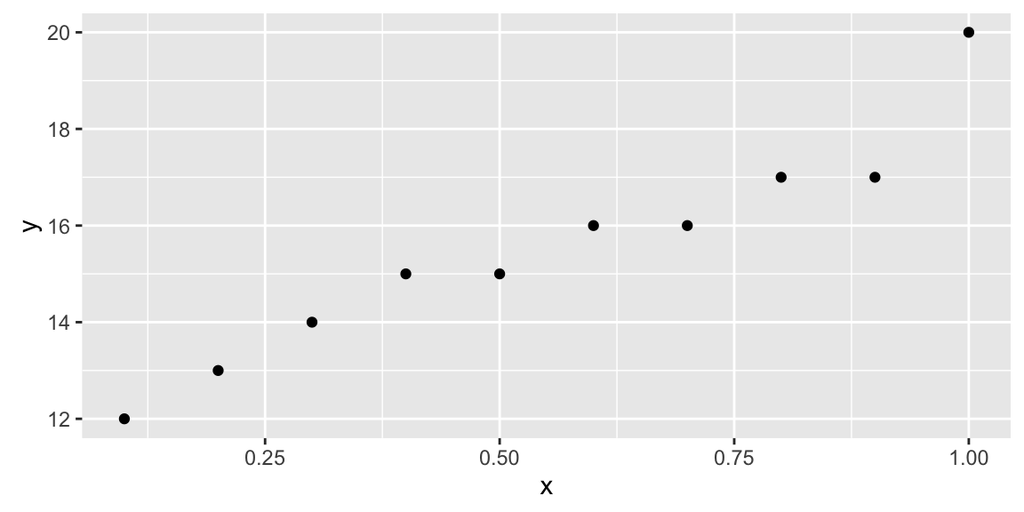

```r
y <- qbinom(seq(.1,1,.1), 20, .75)
x <- seq(.1,1,.1)
qplot(x,y)
```

If we tossed a fair coin 10 times and wanted to know the median number of successes (5th decile) we would enter this:

```r
qbinom(.5,10 ,.5)
```

```
## [1] 5
```

## 3.4 Example rbinom

- rbinom(n, size, prob)

So as an example we have a fictional drug that has a 75% success rate, it’s been tried out on groups of 20 people 1000 times and we want a binomial distribution of the number of success in each trial.

We can enter this:

```r
rbinom(1000, 20, .75)
```

```
##    [1] 12 16 16 16 14 18 15 18 16 17 15 14 17 13 16 17 10 14 19 13  9 18 10
##   [24] 13 17 13 15 15 16 12 14 16 18 14 15 12 14 13 16 13 15 14 19 13 14 15
##   [47] 12 16 15 13 10 16 17 18 13 13 16 16 15 13 13 15 17 13 15 17 18 17 10
##   [70] 15 16 14 17 15 14 13 18 13 18 14 12 12 17 14 16 14 15 14 18 14 17 18
##   [93] 15 14 15 12 13 16 14 11 17 11 17 13 15 17 16 15 14 16 10 14 14 16 15
##  [116] 15 16 14 13 16 17 13 14 14 15 13 16 15 14 17 16 16 14 15 14 14 12 15
##  [139] 14 15 15 14 17 18 13 18 14 12 17 16 15 19 14 15 15 16 15 15 18 15 16
##  [162] 15 13 14 15 12 17 16 16 17 16 15 16 17 18 16 15 12 16 12 15 14 17 13
##  [185] 15 16 13 17 14 13 17 18 13 18 13 18 17 14 14 17 17 18 14 15 15 15 15
##  [208] 13 12 17 14 13 18 14 12 15 12 12 14 16 16 15 13 15 14 16 15 14 17 16
##  [231] 14 14 14 18 16 15 15 17 14 12 13 14 15 16 13 17 16 15 16 13 13 16 13
##  [254] 17 15 16 11 12 13 14 12 13 15 14 13 18 14 16 15 15 15 13 15 17 15 15
##  [277] 13 15 12 15 13 17 12 15 13 15 12 17 12 16 14 12 15 17 11 14 16 18 18
##  [300] 15 15 15 14 17 14 11 15 12 13 18 18 14 14 15 19 15 14 19 15 16 13 17
##  [323] 13 15 15 16 17 14 17 15 14 16 14 18 15 14 15 16 11 17 16 17 18 19 15
```

[output cut: 29 more lines]

And plot it like this:

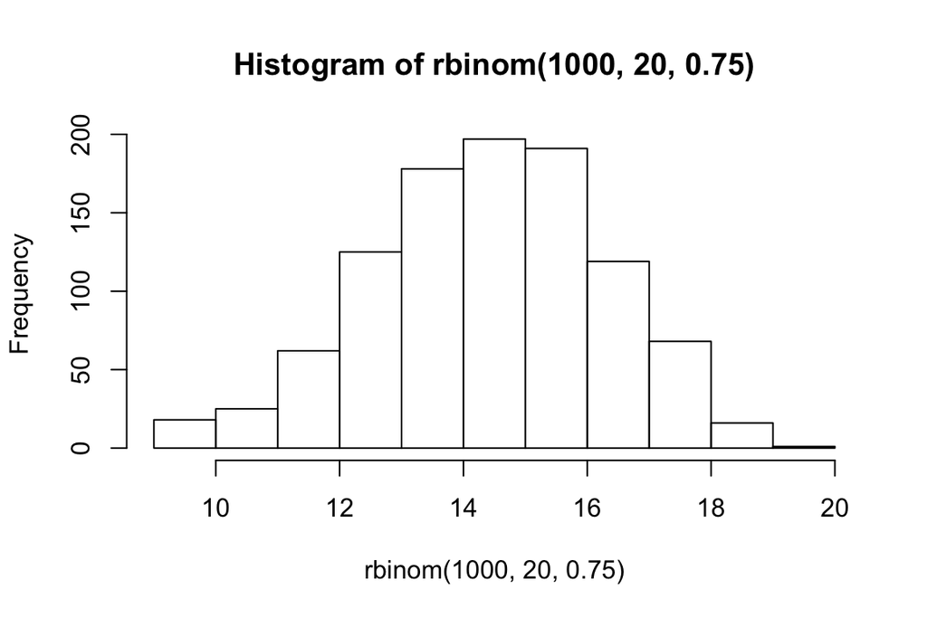

```r
hist(rbinom(1000,20,.75))
```

Or if we wanted to create a binomial distribution of 100 coin flips with a 50% chance of getting either heads or tails:

```r
rbinom(100,1,.5)
```

```
##   [1] 1 1 1 1 0 0 1 1 0 1 1 0 0 0 0 1 0 0 1 0 1 1 1 0 1 1 0 1 1 0 1 1 0 1 0
##  [36] 1 0 0 1 1 1 0 1 0 1 0 0 0 0 0 1 1 1 1 0 0 0 1 1 1 1 1 1 1 1 1 1 0 0 1
##  [71] 1 0 0 1 0 0 0 0 0 0 1 1 0 0 1 1 0 1 0 0 1 1 1 0 0 1 1 0 1 1
```